First, let us load the data and necessary packages:

```r
load("ames_train.Rdata")
library(MASS)
library(dplyr)
library(ggplot2)
library(forcats)
library(scales)
library(BAS)
library(gridExtra)
```

# 1

Make a labeled histogram (with 30 bins) of the ages of the houses in the data set, and describe the distribution.

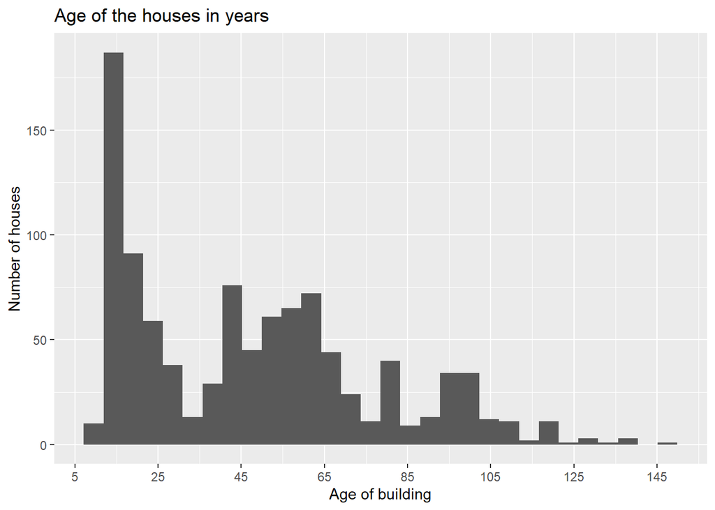

```r
# Create variable for HouseAge
ames_train <- ames_train %>%
  mutate(House.Age = 2020 - Year.Built) # 2020 because that is the current year

ggplot(data = ames_train, aes(x = House.Age)) +
  geom_histogram(bins = 30) +
  labs(title = "Age of the houses in years", x = "Age of building", y = "Number of houses") +
  scale_x_continuous(breaks = seq(5,160,20))
```

# 2

The mantra in real estate is “Location, Location, Location!” Make a graphical display that relates a home price to its neighborhood in Ames, Iowa. Which summary statistics are most appropriate to use for determining the most expensive, least expensive, and most heterogeneous (having the most variation in housing price) neighborhoods? Report which neighborhoods these are based on the summary statistics of your choice. Report the value of your chosen summary statistics for these neighborhoods.

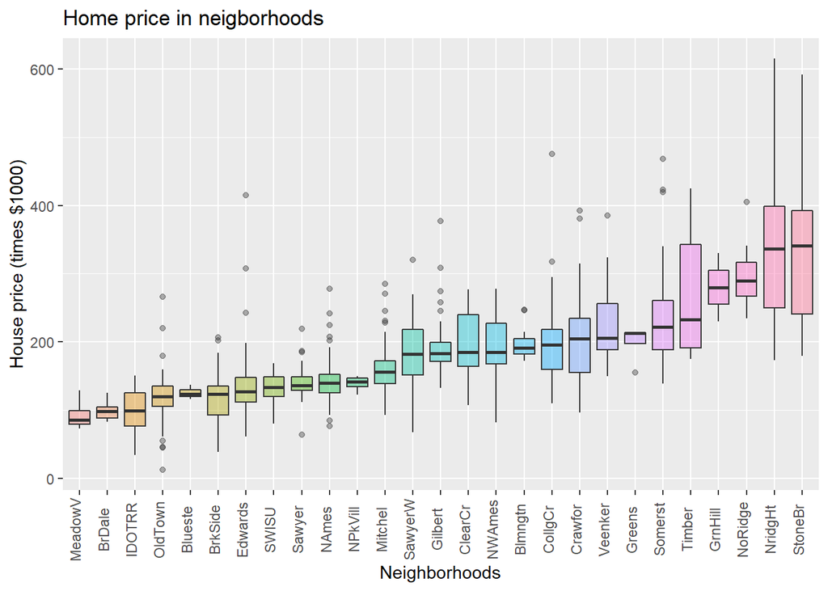

```r
# The graphic for the relation between home price and neighborhood

ames_train %>%
  mutate(Neighborhood = fct_reorder(Neighborhood, price, .fun = "median")) %>%
ggplot(aes(x = Neighborhood, y = price/1000, fill = Neighborhood)) +
  geom_boxplot(alpha = 0.4) +
  labs(title = "Home price in neigborhoods", x = "Neighborhoods", y = "House price (times $1000)") +
  theme(axis.text.x = element_text(angle = 90, vjust = 0.1), legend.position = "none") +
  scale_y_continuous(labels = comma)
```

```r
# Most expensive neighborhood

ames_train %>%
  group_by(Neighborhood) %>%
  summarise(median = median(price), mean = mean(price)) %>%
  arrange(desc(mean))
```

```
## # A tibble: 27 x 3
##    Neighborhood  median    mean
##    <fct>          <dbl>   <dbl>
##  1 StoneBr      340692. 339316.
##  2 NridgHt      336860  333647.
##  3 NoRidge      290000  295845.
##  4 GrnHill      280000  280000
##  5 Timber       232500  265192.
##  6 Somerst      221650  234596.
##  7 Veenker      205750  233650
##  8 Crawfor      205000  204197.
##  9 Blmngtn      191000  198635.
## 10 Greens       212625  198562.
## # ... with 17 more rows
```

```r
# Least expensive neighborhood

ames_train %>%
  group_by(Neighborhood) %>%
  summarise(median = median(price), mean = mean(price)) %>%
  arrange(mean)
```

```
## # A tibble: 27 x 3
##    Neighborhood median    mean
##    <fct>         <dbl>   <dbl>
##  1 MeadowV       85750  92947.
##  2 IDOTRR        99500  97621.
##  3 BrDale        98750  98930
##  4 OldTown      120000 120226.
##  5 BrkSide      124000 122473.
##  6 Blueste      123900 125800
##  7 SWISU        134000 130620.
##  8 Edwards      127250 136322.
##  9 NPkVill      142100 139275
## 10 Sawyer       136000 139313.
## # ... with 17 more rows
```

```r
# Most heterogeneous neighborhood

ames_train %>%
  group_by(Neighborhood) %>%
  summarise(variance = var(price)) %>%
  arrange(desc(variance))
```

```
## # A tibble: 27 x 2
##    Neighborhood     variance
##    <fct>               <dbl>
##  1 StoneBr      15242150036.
##  2 NridgHt      11043676986.
##  3 Timber        7060968802.
##  4 Veenker       5262836111.
##  5 Crawfor       5079065345.
##  6 GrnHill       5000000000
##  7 Somerst       4250973926.
##  8 Edwards       3008701120.
##  9 CollgCr       2786370244.
## 10 SawyerW       2338143789.
## # ... with 17 more rows
```

The graph shows boxplots of the house prices in the neighborhoods of Ames, arranged by their median. I choose median for the graph and to determine the most expensive and least expensive neighborhood, because the mean could be influenced by a possible skew in the prices of certain neighborhoods. Median would not be influenced by such skew. The first two tibbles, however, show that both mean and median provided the same results for the most and least expensive neighborhoods.

The most expensive neighborhood is Stone Brook (StoneBr), with a median house price of $340,692 (and a mean of 339,316 dollars).

The least expensive neighborhood is Meadow Village (MeadowV) with a median house price of just $85,750 (and a mean of 92,947 dollars).

To discover the most heterogeneous neighborhood (most variation in housing price), I used the variance, because the variance indicates how much the values (prices) differ from each other and from the mean. I could also have used the standard deviation, as that is simply the square root of the variance. The results are the same. The most heterogeneous neighborhood is Stone Brook (StoneBr) with a variance of 15242150036 (thus a standard deviation of $123,459.1 which by itself is more than the average housing price of Meadow Village).

# 3

Which variable has the largest number of missing values? Explain why it makes sense that there are so many missing values for this variable.

```r
# Discover number of NAs
Missing <- colSums(is.na(ames_train)) # gather number of NAs per variable in a dataset
Missing[which(Missing == max(Missing))] # extracting variable with most NAs
```

```
## Pool.QC
##     997
```

The variable `Pool.QC` has the most missing values. A value of `NA` in this variable means that a home does not have a pool. 997 out of 1000 houses in this data set did not have a pool, which is not surprising. Iowa is pretty far north in the US and experiences four seasons, with cold winters. I assume that a built-in pool could therefore only be used in the summer. A pool is therefore probably an extreme luxury item like it is here in north-western Europe. The costs are just not worth it for the annual time you can use it.

# 4

We want to predict the natural log of the home prices. Candidate explanatory variables are lot size in square feet (Lot.Area), slope of property (Land.Slope), original construction date (Year.Built), remodel date (Year.Remod.Add), and the number of bedrooms above grade (Bedroom.AbvGr). Pick a model selection or model averaging method covered in the Specialization, and describe how this method works. Then, use this method to find the best multiple regression model for predicting the natural log of the home prices.

```r
# Full model using Bayesian Model Averaging under prior BIC
BMA_ames <- bas.lm(log(price) ~ Lot.Area + Land.Slope + Year.Built + Year.Remod.Add + Bedroom.AbvGr, data = ames_train, prior = "BIC", modelprior = uniform())

summary(BMA_ames)
```

```
##                P(B != 0 | Y)    model 1       model 2      model 3
## Intercept          1.0000000     1.0000     1.0000000     1.000000
## Lot.Area           1.0000000     1.0000     1.0000000     1.000000
## Land.SlopeMod      0.6323994     1.0000     0.0000000     1.000000
## Land.SlopeSev      0.7923033     1.0000     1.0000000     0.000000
## Year.Built         1.0000000     1.0000     1.0000000     1.000000
## Year.Remod.Add     1.0000000     1.0000     1.0000000     1.000000
## Bedroom.AbvGr      1.0000000     1.0000     1.0000000     1.000000
## BF                        NA     1.0000     0.6674353     0.330911
## PostProbs                 NA     0.4752     0.3171000     0.157200
## R2                        NA     0.5625     0.5591000     0.558500
## dim                       NA     7.0000     6.0000000     6.000000
## logmarg                   NA -2198.1673 -2198.5716571 -2199.273250
##                      model 4       model 5
## Intercept          1.0000000  1.000000e+00
## Lot.Area           1.0000000  1.000000e+00
## Land.SlopeMod      0.0000000  0.000000e+00
## Land.SlopeSev      0.0000000  1.000000e+00
## Year.Built         1.0000000  1.000000e+00
## Year.Remod.Add     1.0000000  1.000000e+00
## Bedroom.AbvGr      1.0000000  0.000000e+00
## BF                 0.1061955  1.578929e-12
## PostProbs          0.0505000  0.000000e+00
## R2                 0.5544000  5.316000e-01
## dim                5.0000000  5.000000e+00
## logmarg        -2200.4098178 -2.225342e+03
```

```r
# Predicting Best Predictive Model through BMA

BPM_ames <- predict(BMA_ames, estimator = "BPM", se.fit = TRUE)
variable.names(BPM_ames) # Check which variables are included in the model
```

```
## [1] "Intercept"      "Lot.Area"       "Land.SlopeMod"  "Land.SlopeSev"
## [5] "Year.Built"     "Year.Remod.Add" "Bedroom.AbvGr"
```

```r
# Final model
Final_ames <- lm(log(price) ~ Lot.Area + Land.Slope + Year.Built + Year.Remod.Add + Bedroom.AbvGr, data = ames_train)
```

I used Bayesian Model Averaging to determine the Best Predictive Model. BMA does not use one model, but averages multiple models, which can be used for prediction. As I have to find only one model that is best for predicting the natural log of home prices, I used the BMA model to find the Best Predictive Model. The BMA used the prior ‘BIC’ (Bayesian Information Criterion). This chooses models with the best goodness of fit and introduces a penalty for the number of parameters in the model. This produces a parsimonious model with statistically significant parameters. Estimating the BPM provides the model with predictions closest to that of the full BMA.

Curiously, the best model for predicting the natural log of the home prices is the same as the full model. Therefore, the final model includes `Lot.Area`, `Land.Slope`, `Year.Built`, `Year.Remod.Add` and `Bedroom.AbvGr`.

Below, the model diagnostics are checked. We can see that all conditions are mostly met.

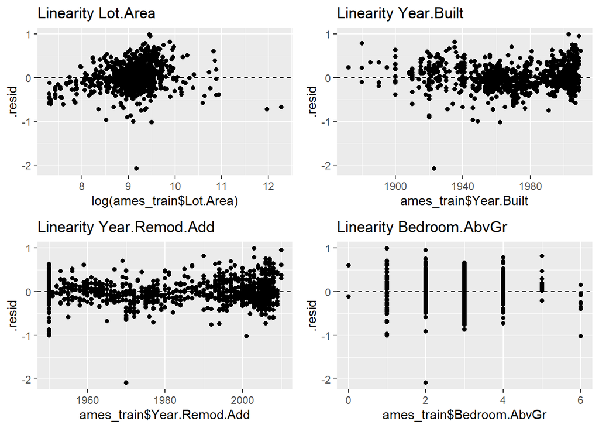

```r
# Linear relationships
p1 <- ggplot(data = Final_ames, aes(x = log(ames_train$Lot.Area), y = .resid)) +
  geom_point() +
  geom_hline(yintercept = 0, linetype = "dashed") +
  labs(title = "Linearity Lot.Area")

p2 <- ggplot(data = Final_ames, aes(x = ames_train$Year.Built, y = .resid)) +
  geom_point() +
  geom_hline(yintercept = 0, linetype = "dashed") +
  labs(title = "Linearity Year.Built")

p3 <- ggplot(data = Final_ames, aes(x = ames_train$Year.Remod.Add, y = .resid)) +
  geom_point() +
  geom_hline(yintercept = 0, linetype = "dashed") +
  labs(title = "Linearity Year.Remod.Add")

p4 <- ggplot(data = Final_ames, aes(x = ames_train$Bedroom.AbvGr, y = .resid)) +
  geom_point() +
  geom_hline(yintercept = 0, linetype = "dashed") +
  labs(title = "Linearity Bedroom.AbvGr")

grid.arrange(p1, p2, p3, p4, nrow = 2)
```

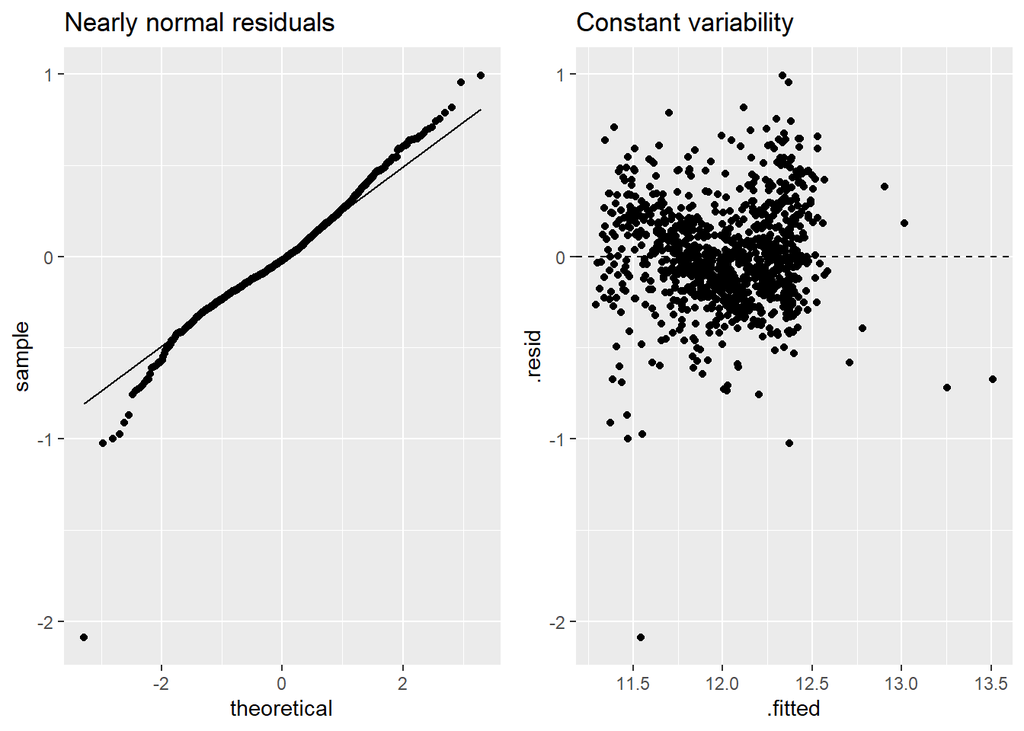

```r
# Nearly normal residuals
Residuals <- data.frame(observations = log(ames_train$price), fitvalues = fitted(Final_ames, estimator = "BMA")) %>%
  mutate(res = observations-fitvalues)

p5 <- ggplot(data = Residuals, aes(sample = res)) +
  geom_qq() +
  geom_qq_line() +
  labs(title = "Nearly normal residuals")

# Constant variability

p6 <- ggplot(data = Final_ames, aes(x = .fitted, y = .resid)) +
  geom_point() +
  geom_hline(yintercept = 0, linetype = "dashed") +
  labs(title = "Constant variability")

grid.arrange(p5, p6, nrow = 1)
```

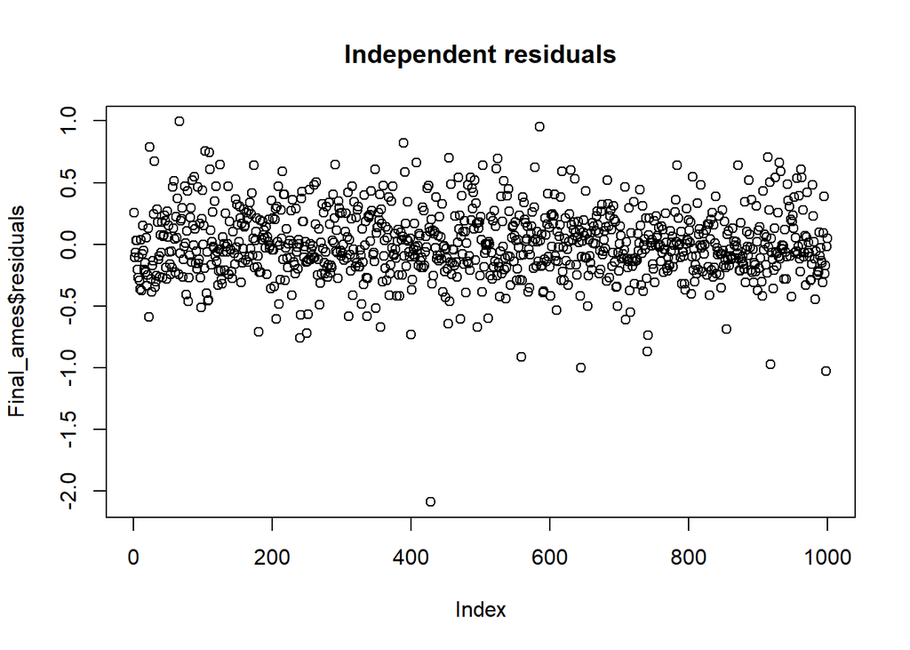

```r
# Independent residuals
plot(Final_ames$residuals, main = "Independent residuals")
```

# 5

Which home has the largest squared residual in the previous analysis (Question 4)? Looking at all the variables in the data set, can you explain why this home stands out from the rest (what factors contribute to the high squared residual and why are those factors relevant)?

```r
# Identify home with largest squared residuals

which(abs(Final_ames$residuals^2) == max(abs(Final_ames$residuals^2)))
```

```
## 428
## 428
```

```r
# Identify characteristics of this home

ames_train <- ames_train %>%
  mutate(log_price = log(price)) # Because we calculated the natural log of the price

StandOut <- ames_train[428,] %>%
  select(PID, Lot.Area, Land.Slope, Year.Built, Year.Remod.Add, Bedroom.AbvGr, log_price)
StandOut
```

```
## # A tibble: 1 x 7
##        PID Lot.Area Land.Slope Year.Built Year.Remod.Add Bedroom.AbvGr log_price
##      <int>    <int> <fct>           <int>          <int>         <int>     <dbl>
## 1   9.02e8     9656 Gtl              1923           1970             2      9.46
```

```r
# Predicted price

predict(Final_ames, StandOut, estimator = "BMA", se.fit = TRUE)$fit
```

```
##        1
## 11.54419
```

```r
# Hidden flaws of the home not included in the variables of the final model

ames_train[428,] %>%
  select(Overall.Qual, Overall.Cond, Exterior.1st, Exter.Cond)
```

```
## # A tibble: 1 x 4
##   Overall.Qual Overall.Cond Exterior.1st Exter.Cond
##          <int>        <int> <fct>        <fct>
## 1            2            2 AsbShng      Fa
```

House 428, with Parcel ID (PID) 902207130, has the largest squared residual. The predicted natural log of the price (11.54) is much higher than the natural log of the actual sale price (9.46), resulting in a high (squared) residual. The model thus predicts a price for this house that is way higher than the actual price. Looking at the other variables, it becomes clear that the house is not under-valued by the seller, but that the model over-values the house. It is a fairly normal house, but the Overall Quality and the Overall Condition both score 2, meaning ‘very poor’. Its exterior is also covered in asbestos, which (in the Netherlands at least) would be a dealbreaker for many potential buyers due to the high risks of asbestos-related diseases. On top of that, this dangerous exterior is only rated ‘fair’.

All these factors (quality aspects) are very relevant for the pricing of a house, but no quality aspects are included in the model, which therefore turns out a prediction that is too high.

# 6

Use the same model selection method you chose in Question 4 to again find the best multiple regression model to predict the natural log of home prices, but this time **replacing Lot.Area with log(Lot.Area)**. Do you arrive at a model including the same set of predictors?

```r
# Full model using BMA under prior BIC like in Question 4

Log_BMA <- bas.lm(log(price) ~ log(Lot.Area) + Land.Slope + Year.Built + Year.Remod.Add + Bedroom.AbvGr, data = ames_train, prior = "BIC", modelprior = uniform())
summary(Log_BMA)
```

```
##                P(B != 0 | Y)    model 1       model 2       model 3
## Intercept         1.00000000     1.0000     1.0000000  1.000000e+00
## log(Lot.Area)     1.00000000     1.0000     1.0000000  1.000000e+00
## Land.SlopeMod     0.39325522     0.0000     1.0000000  0.000000e+00
## Land.SlopeSev     0.03645331     0.0000     0.0000000  1.000000e+00
## Year.Built        1.00000000     1.0000     1.0000000  1.000000e+00
## Year.Remod.Add    1.00000000     1.0000     1.0000000  1.000000e+00
## Bedroom.AbvGr     0.99998941     1.0000     1.0000000  1.000000e+00
## BF                        NA     1.0000     0.6494644  3.866294e-02
## PostProbs                 NA     0.5842     0.3794000  2.260000e-02
## R2                        NA     0.6031     0.6055000  6.032000e-01
## dim                       NA     5.0000     6.0000000  6.000000e+00
## logmarg                   NA -2142.5652 -2142.9968106 -2.145818e+03
##                      model 4       model 5
## Intercept       1.000000e+00  1.000000e+00
## log(Lot.Area)   1.000000e+00  1.000000e+00
## Land.SlopeMod   1.000000e+00  0.000000e+00
## Land.SlopeSev   1.000000e+00  0.000000e+00
## Year.Built      1.000000e+00  1.000000e+00
## Year.Remod.Add  1.000000e+00  1.000000e+00
## Bedroom.AbvGr   1.000000e+00  0.000000e+00
## BF              2.374021e-02  1.412793e-05
## PostProbs       1.390000e-02  0.000000e+00
## R2              6.056000e-01  5.913000e-01
## dim             7.000000e+00  4.000000e+00
## logmarg        -2.146306e+03 -2.153733e+03
```

```r
# Predicting BPM like in Question 4

Log_BPM <- predict(Log_BMA, estimator = "BPM", se.fit = TRUE)
variable.names(Log_BPM)
```

```
## [1] "Intercept"      "log(Lot.Area)"  "Year.Built"     "Year.Remod.Add"
## [5] "Bedroom.AbvGr"
```

```r
# Final model using log(Lot.Area)

LogArea_model <- lm(log(price) ~ log(Lot.Area) + Year.Built + Year.Remod.Add + Bedroom.AbvGr, data = ames_train)
```

I arrive at a model with a different set of predictors. The summary of the BMA shows that `Land.Slope` was excluded from Model 1, which has the highest posterior probability at 0.5842. This also turned out to be the best predictive model, which therefore excludes the `Land.Slope` variable from the full model.

The final `LogArea_model` therefore only includes `log(Lot.Area)`, `Year.Built`, `Year.Remod.Add` and `Bedroom.AbvGr`.

# 7

Do you think it is better to log transform Lot.Area, in terms of assumptions for linear regression? Make graphs of the predicted values of log home price versus the true values of log home price for the regression models selected for Lot.Area and log(Lot.Area). Referencing these two plots, provide a written support that includes a quantitative justification for your answer in the first part of question 7.

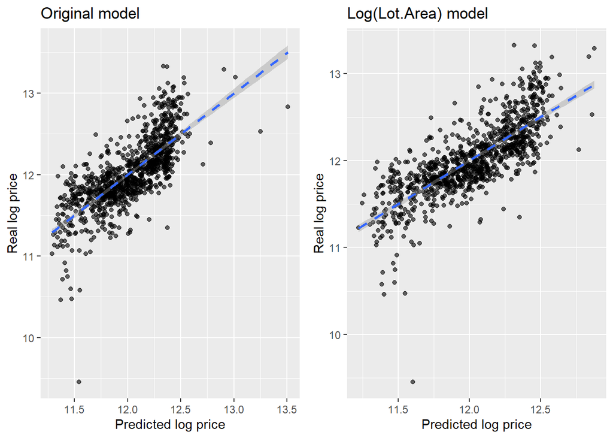

```r
# Plots predicted values versus true values

p8 <- ggplot(data = ames_train, aes(x = Final_ames$fitted.values, y = log_price)) +
  geom_point(alpha = 0.6) +
  geom_smooth(method = "lm", linetype = "dashed") +
  labs(title = "Original model", x = "Predicted log price", y = "Real log price")

p9 <- ggplot(data = ames_train, aes(x = LogArea_model$fitted.values, y = log_price)) +
  geom_point(alpha = 0.6) +
  geom_smooth(method = "lm", linetype = "dashed") +
  labs(title = "Log(Lot.Area) model", x = "Predicted log price", y = "Real log price")

grid.arrange(p8, p9, nrow = 1)
```

```r
# Adjusted R-squared

test <- matrix(c(summary(Final_ames)$adj.r.squared, summary(LogArea_model)$adj.r.squared), ncol = 1)
colnames(test) <- c("Adjusted R Squared")
rownames(test) <- c("Original model", "Log of Lot.Area model")
test <- as.table(test)
test
```

```
##                       Adjusted R Squared
## Original model                 0.5598345
## Log of Lot.Area model          0.6014831
```

The two plots show little difference. However, the `log(Lot.Area)` model shows somewhat less outliers, especially for higher predicted prices. This makes the standard error of the regression line (and of the regression coefficients) smaller and therefore more reliable. On top of that, the adjusted R-squared of the `log(Lot.Area)` model is higher than that of the original model. I therefore think that it is indeed better to log transform Lot.Area for linear regression, especially for higher predicted prices.